# The ACNH Museum: Can you increase your odds?

Created by Julie aka @corbeau0

Last updated April 09 2021

# Introduction

Let’s say you really want Chevre and you really want to find her “naturally” – no amiibos, no Nookazon, no treasure islands. What’s the best way to increase your odds of finding Chevre on a mystery island?

Based on currently knowledge from data mining, the odds are finding a villager are 1/35 (because there are 35 species) multiplied by one over the number in that species. Since there are eight goats, the odds of finding Chevre are:

```r
(1/35)*(1/8)
```

```
## [1] 0.003571429
```

[figure not shown]

# Situation #1: Remove one species

One straightforward of increasing your odds of finding Chevre would be to already have an entire species of your island. That way, 1/35 becomes 1/34.

Let’s say that currently on your island, you have Marina, Octavian, and Zucker. It would be impossible for you to roll an octopus island, so you’ve already decreased the denominator of the first number by one.

1. Marina
2. Octavian
3. Zucker
4. Jeremiah (random)
5. Egbert (random)
6. Bob (random)
7. Wart Jr. (random)
8. Pompom (random)
9. Leopold (random)

```r
(1/(35-1))*(1/8) # 0.003676471
```

```
## [1] 0.003676471
```

Not a big jump, but something.

Let’s save these probabilities so we can look at them later.

```r
attempt1 <- (1/(35-1))*(1/8)
```

# Situation #2: Remove two species

What if we can do better? Can we remove two species? We know that we can have nine villagers on our island while hunting for the empty plot. Let’s look at the species breakdown:

```r
table(villagers$Species)
```

```
##
     ## Alligator  Anteater      Bear      Bird      Bull       Cat   Chicken       Cow
     ##         7         7        15        13         6        23         9         4
     ##       Cub      Deer       Dog      Duck     Eagle  Elephant      Frog      Goat
     ##        16        10        16        17         9        11        18         8
     ##   Gorilla   Hamster     Hippo     Horse  Kangaroo     Koala      Lion    Monkey
     ##         9         8         7        15         8         9         7         8
     ##     Mouse   Octopus   Ostrich   Penguin       Pig    Rabbit     Rhino     Sheep
     ##        15         3        10        13        15        20         6        13
     ##  Squirrel     Tiger      Wolf
     ##        18         7        11
```

If we have all three octopi, then we can squeeze either all the cows, bulls, or rhinos too. Let’s say we have all three octopi and all six bulls.

1. Marina
2. Octavian
3. Zucker
4. Angus
5. Coach
6. Rodeo
7. Stu
8. T-Bone
9. Vic

```r
(1/(35-2))*(1/8) # 0.003787879
```

```
## [1] 0.003787879
```

```r
attempt2 <- (1/(35-2))*(1/8)
```

That’s not bad. Note that it doesn’t matter if it’s cows (4) or bulls (6). The goal of this situation is to eliminate an *entire* species. Whether you have all the octopi (3) + bulls (6) OR octopi (3) + cows (4), your odds are still (1/33)*(1/8).

# Situation #3: Remove one species, fill up the rest with goats

What if you eliminated one species (octopi), and then filled up your island with as many goats as possible?

1. Marina
2. Octavian
3. Zucker
4. Billy
5. Gruff
6. Kidd
7. Nan
8. Pashmina
9. Sherb

At this point, you’re just missing Velma and Chevre, but you really want Chevre. What would your odds be then?

```r
(1/(35-1))*(1/(8-6)) # 0.01470588
```

```
## [1] 0.01470588
```

```r
attempt3 <- (1/(35-1))*(1/(8-6))
```

# Situation #4: Remove two species, fill the rest up with goats

Let’s try again. Let’s say you have all the octopi (3) and all the cows (4), and then filled the rest up with goats.

1. Marina
2. Octavian
3. Zucker
4. Naomi
5. Norma
6. Patty
7. Tipper
8. Billy
9. Nan

```r
(1/(35-2))*(1/(8-2)) # 0.005050505
```

```
## [1] 0.005050505
```

```r
attempt4 <- (1/(35-2))*(1/(8-2))
```

# Situation #5: Have as many goats as possible on your island

Remember that villager hunting is a two-fold process. First, you need to roll the correct species, then you need to roll the correct villager. Let’s cut to the chase and get as many goats as possible (it doesn’t matter who the eighth and ninth villager are) excluding the villager you’re looking for, Chevre.

1. Billy
2. Gruff
3. Kidd
4. Nan
5. Pashmina
6. Sherb
7. Velma
8. Lily (random)
9. Kiki (random)

Now, if you roll a goat island, then you’re guaranteed to roll Chevre.

```r
(1/35)*(1/(8-7)) # 0.02857143
```

```
## [1] 0.02857143
```

```r
attempt5 <- (1/35)*(1/(8-7))
```

Those are pretty good odds. Now you’re more likely to find Chevre than Marina.

# The Ideal Situation

Let’s look at the generated probabilities.

```r
probability <- t(data.frame(attempt1, attempt2, attempt3, attempt4, attempt5))
     head(probability)
```

```
##                 [,1]
     ## attempt1 0.003676471
     ## attempt2 0.003787879
     ## attempt3 0.014705882
     ## attempt4 0.005050505
     ## attempt5 0.028571429
```

So it looks like the ideal situation is to fill up your island with other villagers in the species that you’re looking. We know this applies to goats, but does this apply to other species?

First, let’s calculate the raw probability of finding a villager.

```r
villagers$Probability <- (1/35)*(1/villagers$Species_Count)

     head(villagers)
```

```
##      Name   Species Personality Gender Probability Species_Count
     ## 1 Admiral      Bird      Cranky   Male 0.002197802            13
     ## 2 Agent S  Squirrel       Peppy Female 0.001587302            18
     ## 3   Agnes       Pig        Uchi Female 0.001904762            15
     ## 4      Al   Gorilla        Lazy   Male 0.003174603             9
     ## 5 Alfonso Alligator        Lazy   Male 0.004081633             7
     ## 6   Alice     Koala      Normal Female 0.003174603             9
```

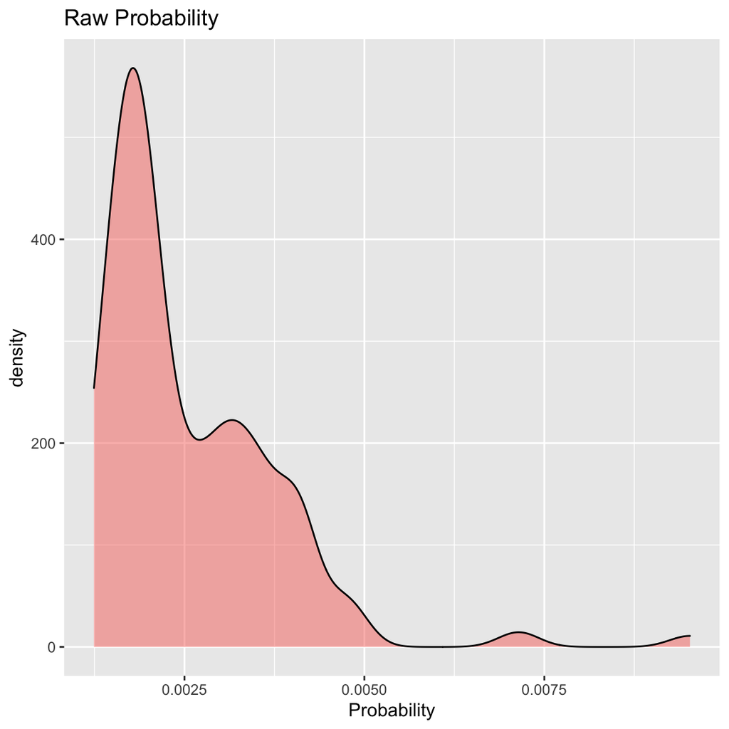

```r
ggplot(villagers, aes(x=Probability)) +
       geom_density(fill = "#F8766D", alpha = 0.5) +
       ggtitle("Raw Probability")
```

Now let’s calculate the “ideal” probability, which would subtract nine from the denominator of the second number

```r
villagers$Ideal_Probability <- (1/35)*(1/(villagers$Species_Count - 9))

     head(villagers$Ideal_Probability)
```

```
## [1]  0.007142857  0.003174603  0.004761905          Inf -0.014285714
     ## [6]          Inf
```

```r
# Get rid of that bad variable so we can recalculate it
     villagers$Ideal_Probability <- NULL

     # Calculate the first number
     villagers$First_Number <- (1/35)

     # Calculate the second number
     villagers$Second_Number <- (1/(villagers$Species_Count - 9))

     # If `Second_Number` is a negative number or is infinite,
     # then replace that value with a value of 1
     villagers$Second_Number <- if_else(villagers$Second_Number < 0 | is.infinite(villagers$Second_Number),
                                        1, # If it's not positive, make it one
                                        villagers$Second_Number) # If it is positive, keep it the same

     # Recalculate `Ideal_Probability`
     villagers$Ideal_Probability <- villagers$First_Number*villagers$Second_Number

     # Look at the data
     head(villagers$Ideal_Probability)
```

```
## [1] 0.007142857 0.003174603 0.004761905 0.028571429 0.028571429 0.028571429
```

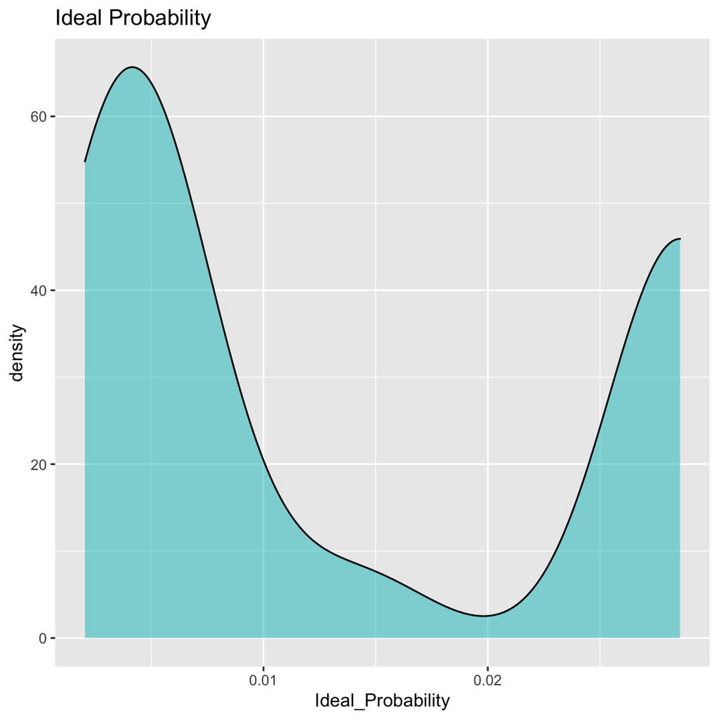

```r
ggplot(villagers, aes(x=Ideal_Probability)) +
       geom_density(fill = "#00BFC4", alpha = 0.5) +
       ggtitle("Ideal Probability")
```

Let’s look at raw probability and ideal probability simultaneously.

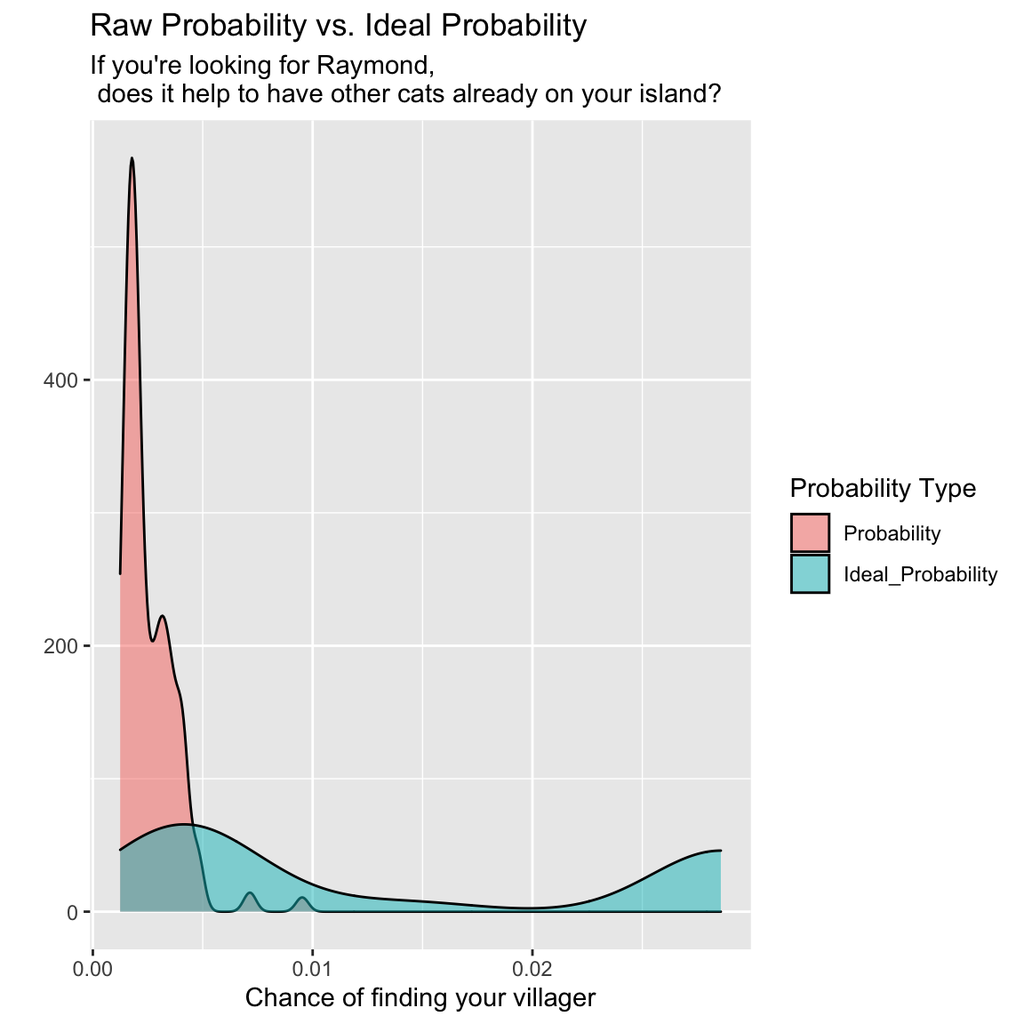

```r
melt <- reshape2::melt(villagers,
                  id.vars = c("Name", "Species", "Personality", "Gender",
                              "Species_Count", "First_Number", "Second_Number"))

     ggplot(melt, aes(x=value)) +
       geom_density(aes(fill=variable), alpha = 0.5) +
       guides(fill=guide_legend(title="Probability Type")) +
       xlab("Chance of finding your villager") + ylab(" ") + ggtitle("Raw Probability vs. Ideal Probability") +
       labs(subtitle = "If you're looking for Raymond,\n does it help to have other cats already on your island?")
```

```r
# Just get the variables we want to look at
     table <- data.frame(villagers[c("Species", "Probability", "Ideal_Probability")])

     # Average them by Species
     table <- table %>%
        group_by(Species) %>%
        summarise_all(list(~ .[!is.na(.)][1]))

     # Round numbers so they're not too long
     table$Probability <- round(table$Probability, digits=5)
     table$Ideal_Probability <- round(table$Ideal_Probability, digits=5)

     # A nice html table
     table %>%
       kbl(caption = "Raw vs. Ideal Probability") %>%
       kable_styling(bootstrap_options = c("striped", "hover", "condensed"), full_width = F) %>%
       scroll_box(width = "100%", height = "500px")
```

Raw vs. Ideal Probability

| Species | Probability | Ideal_Probability |
| --- | --- | --- |
| Alligator | 0.00408 | 0.02857 |
| Anteater | 0.00408 | 0.02857 |
| Bear | 0.00190 | 0.00476 |
| Bird | 0.00220 | 0.00714 |
| Bull | 0.00476 | 0.02857 |
| Cat | 0.00124 | 0.00204 |
| Chicken | 0.00317 | 0.02857 |
| Cow | 0.00714 | 0.02857 |
| Cub | 0.00179 | 0.00408 |
| Deer | 0.00286 | 0.02857 |
| Dog | 0.00179 | 0.00408 |
| Duck | 0.00168 | 0.00357 |
| Eagle | 0.00317 | 0.02857 |
| Elephant | 0.00260 | 0.01429 |
| Frog | 0.00159 | 0.00317 |
| Goat | 0.00357 | 0.02857 |
| Gorilla | 0.00317 | 0.02857 |
| Hamster | 0.00357 | 0.02857 |
| Hippo | 0.00408 | 0.02857 |
| Horse | 0.00190 | 0.00476 |
| Kangaroo | 0.00357 | 0.02857 |
| Koala | 0.00317 | 0.02857 |
| Lion | 0.00408 | 0.02857 |
| Monkey | 0.00357 | 0.02857 |
| Mouse | 0.00190 | 0.00476 |
| Octopus | 0.00952 | 0.02857 |
| Ostrich | 0.00286 | 0.02857 |
| Penguin | 0.00220 | 0.00714 |
| Pig | 0.00190 | 0.00476 |
| Rabbit | 0.00143 | 0.00260 |
| Rhino | 0.00476 | 0.02857 |
| Sheep | 0.00220 | 0.00714 |
| Squirrel | 0.00159 | 0.00317 |
| Tiger | 0.00408 | 0.02857 |
| Wolf | 0.00260 | 0.01429 |

Visualizations are nice, but we should be able to subtract `Probability` from `Ideal_Probability` and not have any negative numbers. This shows that there are *no* negative number, which means that no matter what species you’re looking for, it’ll benefit you to have as many villagers of your dreamie’s species as possible.

```r
test <- villagers$Ideal_Probability - villagers$Probability
     head(test)
```

```
## [1] 0.004945055 0.001587302 0.002857143 0.025396825 0.024489796 0.025396825
```

```r
sum(test < 0) # No negative numbers
```

```
## [1] 0
```

# Conclusion

We’ve concluded that the best way to increase your odds of finding your dream villager is to have as many villagers of that species on your island when you go hunt. (Don’t ask me the best way to do that though!)

```r
info <- data.frame(table(villagers$Species))
     names(info)[names(info) == "Var1"] <- "Species"
     names(info)[names(info) == "Freq"] <- "vals"
```

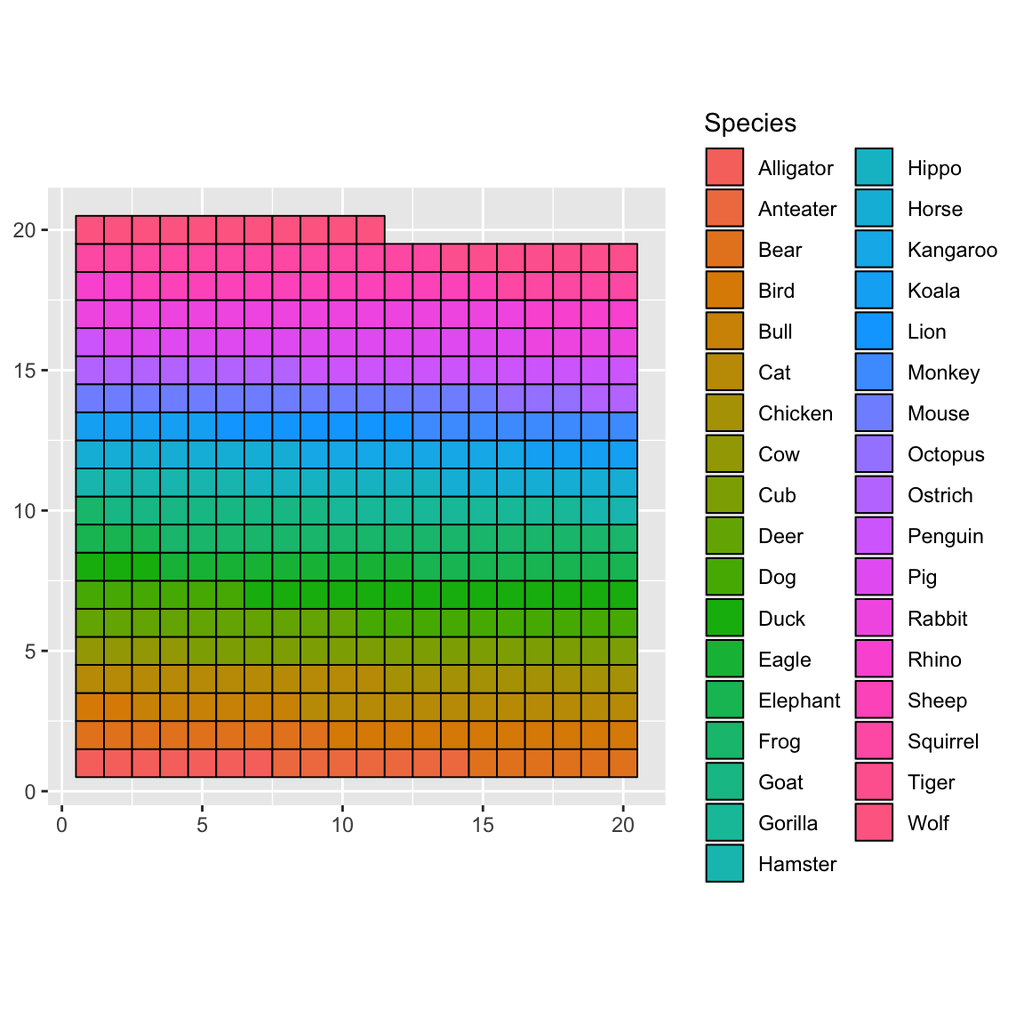

```r
info %>%
       ggplot(aes(fill = Species, values = vals)) +
       geom_waffle(n_rows = 20, size = 0.33, colour = "black", flip = TRUE) +
       coord_equal()
```